# Main file TFA reexam (R part)

Lars Relund Nielsen

In the following, use R to answer the questions/assignments. Your solutions must be written in a R Markdown (Rmd) file. This file must include your code and a (brief) comment for each question. For example, “The three companies with smallest profit are …” or “The plot shows that …”.

An R markdown template file is given in the appendix that you may use as a starting point.

You may load and use the following packages:

```r
library(tidyverse)
library(skimr)
```

# R - Assignment 1 (10%)

Consider the vector:

```r
v <- c(9, 19, 2, 8, NA, 12, 9, 23, NA, 34)
v
```

```
##  [1]  9 19  2  8 NA 12  9 23 NA 34
```

Use R to answer the following questions.

## Question 1

Is any of the entries in `v` below or equal to 2?

Guiding solution:

```r
any(v <= 2)
```

```
## [1] TRUE
```

Yes since the vector contains 2.

## Question 2

Is all of the entries in `v` above or equal to 2?

Guiding solution:

```r
all(v >= 2)
```

```
## [1] NA
```

We don’t know since we have missing values.

## Question 3

Does `v` have missing values?

Guiding solution:

```r
any(is.na(v))
```

```
## [1] TRUE
```

Yes, since `v` contains `NA` values.

## Question 4

Which entries in `v` are above 10? You must return the indices, e.g. the index of `v[3]` is 3.

Guiding solution:

```r
which(v > 10)
```

```
## [1]  2  6  8 10
```

The index are 2, 6, 8, 10.

## Question 5

Create a vector `res` where `res[i]` is equal to `v[i]` if `v[i]` is less than 10 and otherwise zero (also if `v[i]` is `NA`).

Guiding solution:

```r
res <- if_else(v < 10, v, 0, 0)
res
```

```
##  [1] 9 0 2 8 0 0 9 0 0 0
```

We use `if_else` to set values.

# R - Assignment 2 (20%)

The dataset `titanic`, given in the appendix, lists approx. 1300 passengers on Titanic. The column/variables are:

- `pclass`: Passenger class (1 = 1st; 2 = 2nd; 3 = 3rd).
- `survived`: Survival (0 = No; 1 = Yes).
- `name`: Name.
- `sex`: Sex.
- `age`: Age.
- `fare`: Passenger Fare.
- `cabin`: Cabin number.
- `embarked`: Port of embarkation (C = Cherbourg; Q = Queenstown; S = Southampton).
- `boat`: Lifeboat number.

You can read the dataset file `titanic.csv` into the dataset `dat` using

```r
dat <- read_csv("titanic.csv")
```

Use the *dplyr* package in *tidyverse* to calculate relevant summary tables (data frames) and answer the following questions.

## Question 1

Create a new column named `male` which is true if the person is a male.

Guiding solution:

```r
dat <- dat %>%
  mutate(male = if_else(sex == "male", TRUE, FALSE))
dat
```

```
## # A tibble: 1,309 × 10
##    pclass survived name                      sex      age  fare cabin embarked boat  male
##     <dbl>    <dbl> <chr>                     <chr>  <dbl> <dbl> <chr> <chr>    <chr> <lgl>
##  1      1        1 Allen, Miss. Elisabeth W… female 29    211.  B5    S        2     FALSE
##  2      1        1 Allison, Master. Hudson … male    0.92 152.  C22 … S        11    TRUE
##  3      1        0 Allison, Miss. Helen Lor… female  2    152.  C22 … S        <NA>  FALSE
##  4      1        0 Allison, Mr. Hudson Josh… male   30    152.  C22 … S        <NA>  TRUE
##  5      1        0 Allison, Mrs. Hudson J C… female 25    152.  C22 … S        <NA>  FALSE
##  6      1        1 Anderson, Mr. Harry       male   48     26.6 E12   S        3     TRUE
##  7      1        1 Andrews, Miss. Kornelia … female 63     78.0 D7    S        10    FALSE
##  8      1        0 Andrews, Mr. Thomas Jr    male   39      0   A36   S        <NA>  TRUE
##  9      1        1 Appleton, Mrs. Edward Da… female 53     51.5 C101  S        D     FALSE
## 10      1        0 Artagaveytia, Mr. Ramon   male   71     49.5 <NA>  C        <NA>  TRUE
## # … with 1,299 more rows
```

We use `if_else` to set the new column.

## Question 2

How many persons are we considering, how many men (in percentage) and how many survived?

Guiding solution:

```r
skim(dat)
```

Data summary

| Name | dat |
| --- | --- |
| Number of rows | 1309 |
| Number of columns | 10 |
| _______________________ |  |
| Column type frequency: |  |
| character | 5 |
| logical | 1 |
| numeric | 4 |
| ________________________ |  |
| Group variables | None |

**Variable type: character**

| skim_variable | n_missing | complete_rate | min | max | empty | n_unique | whitespace |
| --- | --- | --- | --- | --- | --- | --- | --- |
| name | 0 | 1.00 | 12 | 82 | 0 | 1307 | 0 |
| sex | 0 | 1.00 | 4 | 6 | 0 | 2 | 0 |
| cabin | 1014 | 0.23 | 1 | 15 | 0 | 186 | 0 |
| embarked | 2 | 1.00 | 1 | 1 | 0 | 3 | 0 |
| boat | 823 | 0.37 | 1 | 7 | 0 | 27 | 0 |

**Variable type: logical**

| skim_variable | n_missing | complete_rate | mean | count |
| --- | --- | --- | --- | --- |
| male | 0 | 1 | 0.64 | TRU: 843, FAL: 466 |

**Variable type: numeric**

| skim_variable | n_missing | complete_rate | mean | sd | p0 | p25 | p50 | p75 | p100 | hist |
| --- | --- | --- | --- | --- | --- | --- | --- | --- | --- | --- |
| pclass | 0 | 1.0 | 2.29 | 0.84 | 1.00 | 2.0 | 3.00 | 3.00 | 3.00 | ▃▁▃▁▇ |
| survived | 0 | 1.0 | 0.38 | 0.49 | 0.00 | 0.0 | 0.00 | 1.00 | 1.00 | ▇▁▁▁▅ |
| age | 263 | 0.8 | 29.88 | 14.41 | 0.17 | 21.0 | 28.00 | 39.00 | 80.00 | ▂▇▅▂▁ |
| fare | 1 | 1.0 | 33.30 | 51.76 | 0.00 | 7.9 | 14.45 | 31.27 | 512.33 | ▇▁▁▁▁ |

From the output we can consider 1309 persons of which approx 64% are males. Approx. 38% of the passangers survived.

## Question 3

How many of the females survived in percent (and how many males)?

Guiding solution:

```r
dat %>%
  group_by(sex, survived) %>%
  count() %>%
  group_by(sex) %>%
  mutate(rate = n/sum(n))
```

```
## # A tibble: 4 × 4
## # Groups:   sex [2]
##   sex    survived     n  rate
##   <chr>     <dbl> <int> <dbl>
## 1 female        0   127 0.273
## 2 female        1   339 0.727
## 3 male          0   682 0.809
## 4 male          1   161 0.191
```

```r
# Alternatively
res <- dat %>%
  group_by(male) %>%
  summarise(survived = sum(survived)/n()) %>%
  print()
```

```
## # A tibble: 2 × 2
##   male  survived
##   <lgl>    <dbl>
## 1 FALSE    0.727
## 2 TRUE     0.191
```

The survival rate for women and men are 73 and 19 percent, respectively.

## Question 4

Define children as people with age below 19. How many children survived?

Guiding solution:

```r
res <- dat %>%
  filter(age < 19, survived == TRUE) %>%
  nrow() %>%
  print()
```

```
## [1] 95
```

95 childern survived.

## Question 5

Did relatively more people survive at first class compared to third class?

Guiding solution:

```r
res <- dat %>%
  group_by(pclass) %>%
  summarise(rate = sum(survived)/n()) %>%
  print()
```

```
## # A tibble: 3 × 2
##   pclass  rate
##    <dbl> <dbl>
## 1      1 0.619
## 2      2 0.430
## 3      3 0.255
```

There seems to be a big difference in survival rate between first class (62%) and third class (26%).

## Question 6

How many persons that entered a lifeboat did die in percent?

Guiding solution:

```r
res <- dat %>%
  filter(!is.na(boat)) %>%
  summarise(rate = 1-sum(survived)/n()) %>%
  print()
```

```
## # A tibble: 1 × 1
##     rate
##    <dbl>
## 1 0.0185
```

The survival rate when entered the lifeboat was high. Only 1.85% died.

## Question 7

How many persons with `Hansen` in their name survived?

Guiding solution:

```r
dat %>%
  filter(str_detect(name, "Hansen"))
```

```
## # A tibble: 6 × 10
##   pclass survived name                        sex     age  fare cabin embarked boat  male
##    <dbl>    <dbl> <chr>                       <chr> <dbl> <dbl> <chr> <chr>    <chr> <lgl>
## 1      3        0 Hansen, Mr. Claus Peter     male     41 14.1  <NA>  S        <NA>  TRUE
## 2      3        0 Hansen, Mr. Henrik Juul     male     26  7.85 <NA>  S        <NA>  TRUE
## 3      3        0 Hansen, Mr. Henry Damsgaard male     21  7.85 <NA>  S        <NA>  TRUE
## 4      3        1 Hansen, Mrs. Claus Peter (… fema…    45 14.1  <NA>  S        11    FALSE
## 5      3        0 Moen, Mr. Sigurd Hansen     male     25  7.65 F G73 S        <NA>  TRUE
## 6      3        0 Nysveen, Mr. Johan Hansen   male     61  6.24 <NA>  S        <NA>  TRUE
```

Only a single person survived.

# R - Assignment 3 (20%)

Answer this assignment using the *ggplot2* package in *tidyverse* (you might need dplyr for preparing the datasets you want to plot). We work with the dataset `titanic` from Assignment 2 which can be read using:

```r
dat <- read_csv("titanic.csv")
```

## Question 1

Create a visualization showing the number of persons embarking the different harbors with the following features:

- Number of persons is represented using bars.
- Informative figure title and axis titles are given.
- The labels on the x-axis are the harbor names (not abbreviations).

What harbor was the main departure harbor?

Guiding solution:

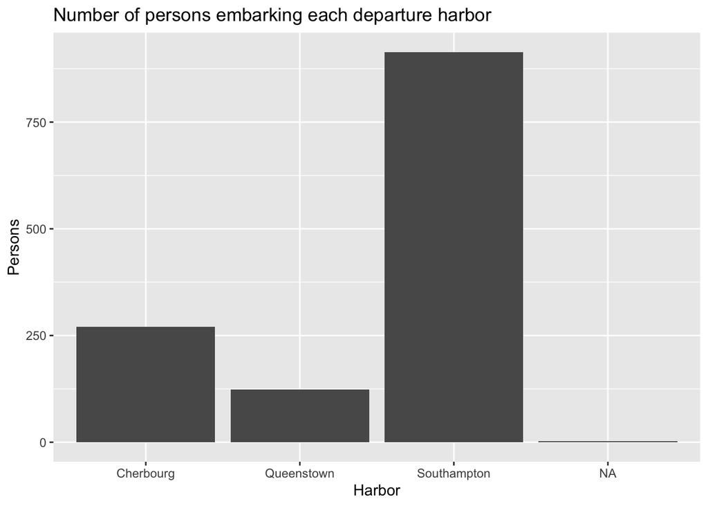

```r
dat <- dat %>% mutate(harbor = case_when(
  embarked == "C" ~ "Cherbourg",
  embarked == "Q" ~ "Queenstown",
  embarked == "S" ~ "Southampton",
  TRUE ~ NA_character_
))
dat %>%
  ggplot(aes(x = harbor)) +
  geom_bar() +
  labs(title = "Number of persons embarking each departure harbor",
       x = "Harbor",
       y = "Persons")
```

The main harbor was Southampton.

## Question 2

Create a visualization showing the age distribution of the persons with the following features:

- Number of persons is represented using a histogram.
- Informative figure title and axis titles are given.

Where there most people on board in their twenties or thirties?

Guiding solution:

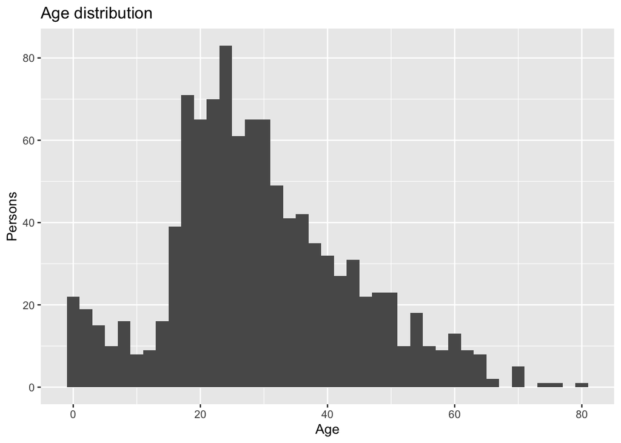

```r
dat %>%
  ggplot(aes(x = age)) +
  geom_histogram(binwidth = 2) +
  labs(title = "Age distribution",
       x = "Age",
       y = "Persons")
```

There where most people in their twenties.

## Question 3

Create a visualization showing the fare as a function of age with the following features:

- Different colors are used for each sex.
- Informative figure title and axis titles are given.
- A trend line for each sex is added using `geom_smooth`.

Based on the trend lines, do females in general pay more for a ticket?

Guiding solution:

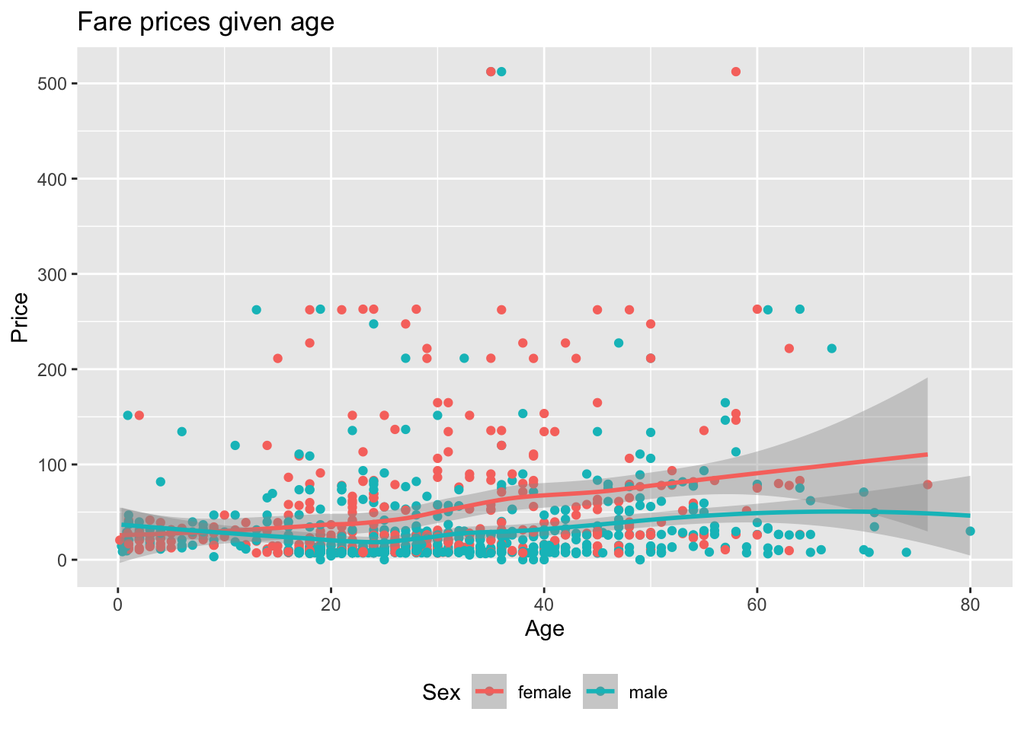

```r
dat %>% ggplot(aes(x = age, y = fare, color = sex)) +
  geom_point() +
  geom_smooth() +
  labs(title = "Fare prices given age",
       x = "Age",
       y = "Price",
       color = "Sex") +
  theme(legend.position = "bottom")
```

Based on the trend lines females in general pays more than males.

## Question 4

Create a visualization showing the survival rate for each passenger class with the following features:

- Bars are used for each passenger class.
- All bars have same height (100 %).
- Colors are used to identify who survived and did not survived.
- Informative figure title and axis titles are given.

Is the survival rate different on first and third class?

Guiding solution:

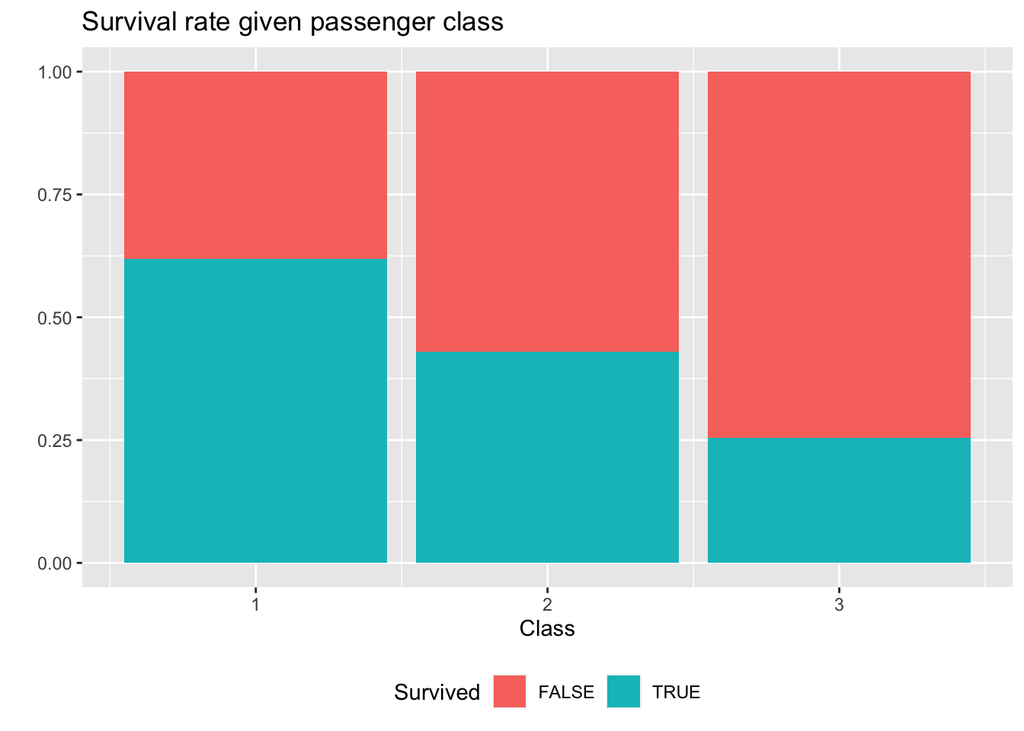

```r
dat %>%
  ggplot(aes(x = pclass, fill = as.logical(survived))) +
  geom_bar(position="fill") +
  labs(title = "Survival rate given passenger class",
       x = "Class",
       y = "",
       fill = "Survived") +
  theme(legend.position = "bottom")
```

Based on the plot most people survived at first classs.

## Question 5

Let column `level` denote the the first letter in `cabin`. Create a visualization showing the variance in fare prices with the following features:

- Ignore rows with missing `level`.
- Variation is shown using a boxplot.
- Informative figure title and axis titles are given.

Is the fare price different at the B and C level?

Guiding solution:

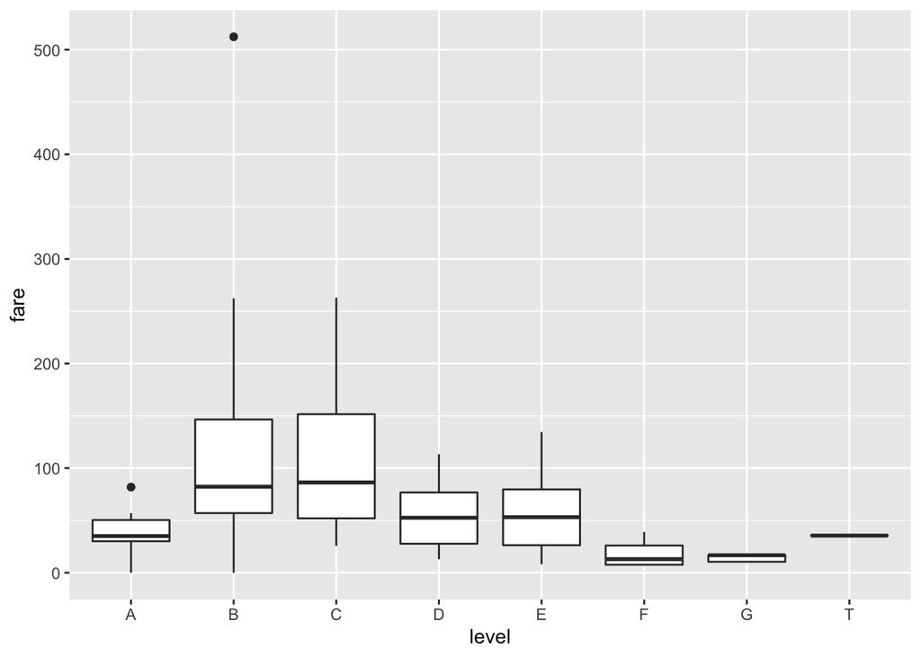

```r
dat <- dat %>%
  mutate(level = str_sub(cabin, 1, 1))

  dat %>% filter(!is.na(level)) %>%
    ggplot(aes(x = level, y = fare)) +
    geom_boxplot()
```

Based on the plot the fare prices at B and C level are more or less the same.